# Kontingenzanalyse

Manfred Brill

Sommersemester 2021

# 1 Voraussetzungen

Dieses Dokument setzt voraus, dass Sie die grundlegenden Konzepte von R kennen.

# 2 Daten

Wir betrachten das Beispiel der *Wohnsituation*, ein Datensatz, der Bamberg und Baur (Günter Bamberg 1993) entnommen ist. Da die Daten das Semikolon als Trenner verwenden lesen wir sie mit *read_csv2* ein und speichern sie auf dem Objekt *wohnungen*.

```r
# Trenner auf Semikolon setzen
wohnungen <- read_csv2("data/wohnungen.csv")
```

# 3 Kontingenztabellen

Wir erzeugen aus den Daten eine Kontingenztabelle - andere Bezeichnungen dafür sind Kreuztabellen oder in Microsoft Excel Pivot-Tabelle. Dazu verwenden wir die Funktion *table*.

```r
wohnungen.table <- table(wohnungen)
head(wohnungen.table)
```

```
##         Zimmer
## Personen 1 2 3 4
##        2 2 0 3 3
##        3 0 1 2 3
##        4 0 1 2 1
##        5 0 0 0 2
```

Alternativen zu *table* sind die Funktionen *xtable* oder *prop.table*. Die Funktion *prop.table* erzeugt eine Kontingenztabelle mit relativen Häufigkeiten.

Wir haben die Randhäufigkeiten für eine Kontingenztabelle eingeführt, dazu verwenden wir die Funktion *addmargins*:

```r
tabelle <- addmargins(wohnungen.table)
```

Wenn wir relative Häufigkeiten darstellen möchten, können wir das mit einer Kombination aus *addmargins* und *prop.table* erzeugen:

```r
addmargins(prop.table(wohnungen.table))
```

```
##         Zimmer
## Personen    1    2    3    4  Sum
##      2   0.10 0.00 0.15 0.15 0.40
##      3   0.00 0.05 0.10 0.15 0.30
##      4   0.00 0.05 0.10 0.05 0.20
##      5   0.00 0.00 0.00 0.10 0.10
##      Sum 0.10 0.10 0.35 0.45 1.00
```

Neben der Möglichkeit, diese Tabelle wie in der R-Konsole darzustellen können wir die Funktion *kable* verwenden:

```r
kable(tabelle,
      caption="Kontingenztabelle mit Randhäufigkeiten",
      align="l") %>%
      kable_styling(bootstrap_options = c("striped", "condensed"),
                full_width = T,
                position = "center")
```

Kontingenztabelle mit Randhäufigkeiten

|  | 1 | 2 | 3 | 4 | Sum |
| --- | --- | --- | --- | --- | --- |
| 2 | 2 | 0 | 3 | 3 | 8 |
| 3 | 0 | 1 | 2 | 3 | 6 |
| 4 | 0 | 1 | 2 | 1 | 4 |
| 5 | 0 | 0 | 0 | 2 | 2 |
| Sum | 2 | 2 | 7 | 9 | 20 |

# 4 Kontingenz-Analyse

Für die Kontingenzanalyse gibt es eine Reihe von Parametern. Diese beruhen alle auf dem Chi-Quadrat Parameter, der jedoch den Nachteil hat, dass er schwer zu interpretieren ist.

Wir verwenden den Kontingenzparameter und den korrigierten Kontingenzparameter. Ein weiterer normierter Parameter ist Cramer’s V. ChiQuadrat und den korrigierten) Kontingenzkoeffizienten erhalten wir im Package *vcd* mit der Funktion *assocstats*. Wir übergeben die mit *table* erstellte Kontingenztabelle.

Den Wert für den Chi-quadrat Parameter erhalten wir in der Ausgabe der Funktion, als *Pearson X2*. Den nicht korrigierten Kontingenzkoeffizienten C finden wir ebenfalls in der Ausgabe oder mit der Bezeichnung *cont*. Cramer’s V erhalten wir analog.

```r
assocstats(wohnungen.table)
```

```
##                     X^2 df P(> X^2)
## Likelihood Ratio 9.7216  9  0.37349
## Pearson          7.9762  9  0.53655
##
## Phi-Coefficient   : NA
## Contingency Coeff.: 0.534
## Cramer's V        : 0.365
```

```r
assocstats(wohnungen.table)$cont
```

```
## [1] 0.534
```

```r
assocstats(wohnungen.table)$cramer
```

```
## [1] 0.365
```

Das Package *DescTools* enthält eine ganze Reihe von Funktionen, die diese und noch weitere Parameter berechnen. Den unkorrigierten und den korrigierten Kontingenzkoeffizienten (mit dem Attribut *correct=TRUE*) erhalten wir mit der Funktion *ContCoef*, Cramer’s V mit *CramerV*. Diese Funktionen haben den Vorteil, dass wir direkt mit zwei Spalten eines Datensatzes arbeiten können, ohne vorher eine Kontingenztabelle bilden zu müssen.

```r
ContCoef(wohnungen.table)
```

```
## [1] 0.534
```

```r
ContCoef(wohnungen.table, correct=TRUE)
```

```
## [1] 0.617
```

```r
CramerV(wohnungen.table)
```

```
## [1] 0.365
```

# 5 Visualisierung von Kontingenztabellen

Wir betrachten hier die folgenden Möglichkeiten einer Visualisierung:

- Balkendiagramme
- Streuungsdiagramme
- Mosaikplots
- Heatmaps

## 5.1 Balkendiagramme

Es liegt nahe jedes der beiden Merkmale individuell in einem Balkendiagramm zu visualisieren.

[figure not shown]

```r
ggplot(data=wohnungen) +
  geom_bar(mapping=aes(x=Personen,
                       fill=myPalette[1],
                       show.legend=FALSE)) +
  labs(
         title="Datensatz Familienzimmer mit Visualisierung der Häufigkeiten",
         x="Anzahl der  Zimmer in der Wohnung",
         y="Absolut Häufigkeiten"
  )
```

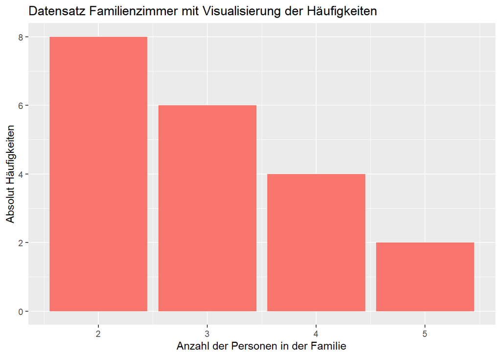

```r
ggplot(data=wohnungen) +
  geom_bar(mapping=aes(x=Personen,
                       fill=myPalette[1]),
                       show.legend=FALSE) +
  labs(
         title="Datensatz Familienzimmer mit Visualisierung der Häufigkeiten",
         x="Anzahl der Personen in der Familie",
         y="Absolut Häufigkeiten"
  )
```

Wir färben die Balken für die Visualisierung der Häufigkeiten eines Merkmals mit Hilfe der Häufigkeiten des zweiten Merkmals. Achten Sie darauf bei solchen Darstellunen *immer* mit einer Legende zu arbeiten.

Hier eine Serie von Abbildungen, die die verschiedenen Möglichkeiten zeigt:

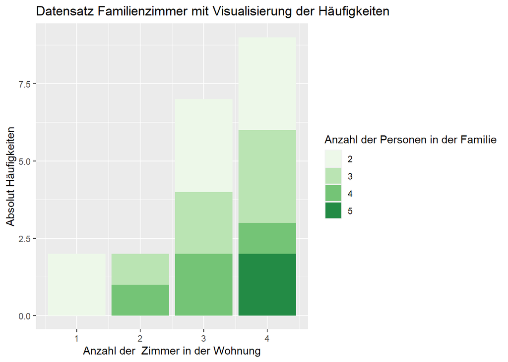

```r
ggplot(data=wohnungen) +
  geom_bar(mapping=aes(x=Zimmer, fill=factor(Personen))) +
  scale_fill_brewer(palette="Greens") +
  labs(
         title="Datensatz Familienzimmer mit Visualisierung der Häufigkeiten",
         x="Anzahl der  Zimmer in der Wohnung",
         y="Absolut Häufigkeiten"
  ) +
  guides(fill=guide_legend(title="Anzahl der Personen in der Familie"))
```

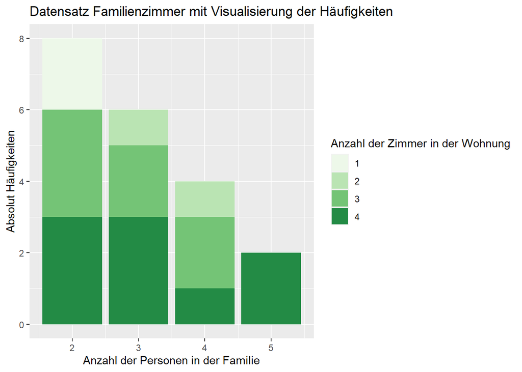

```r
ggplot(data=wohnungen) +
  geom_bar(mapping=aes(x=Personen, fill=factor(Zimmer))) +
  scale_fill_brewer(palette="Greens") +
  labs(
         title="Datensatz Familienzimmer mit Visualisierung der Häufigkeiten",
         x="Anzahl der Personen in der Familie",
         y="Absolut Häufigkeiten"
  ) +
  guides(fill=guide_legend(title="Anzahl der Zimmer in der Wohnung"))
```

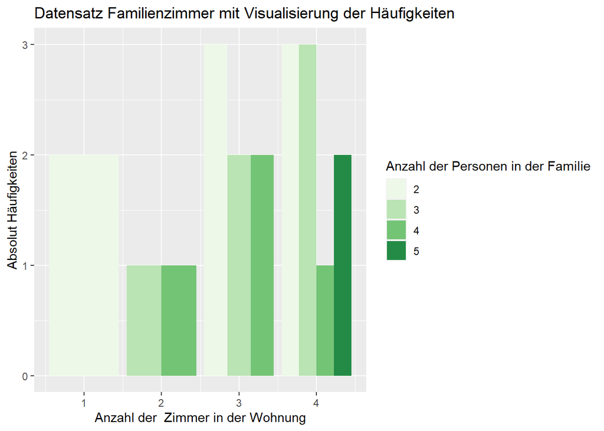

```r
ggplot(data=wohnungen) +
  geom_bar(mapping=aes(x=Zimmer, fill=factor(Personen)),
           position="dodge") +
  scale_fill_brewer(palette="Greens") +
     labs(
         title="Datensatz Familienzimmer mit Visualisierung der Häufigkeiten",
         x="Anzahl der  Zimmer in der Wohnung",
         y="Absolut Häufigkeiten"
  ) +
  guides(fill=guide_legend(title="Anzahl der Personen in der Familie"))
```

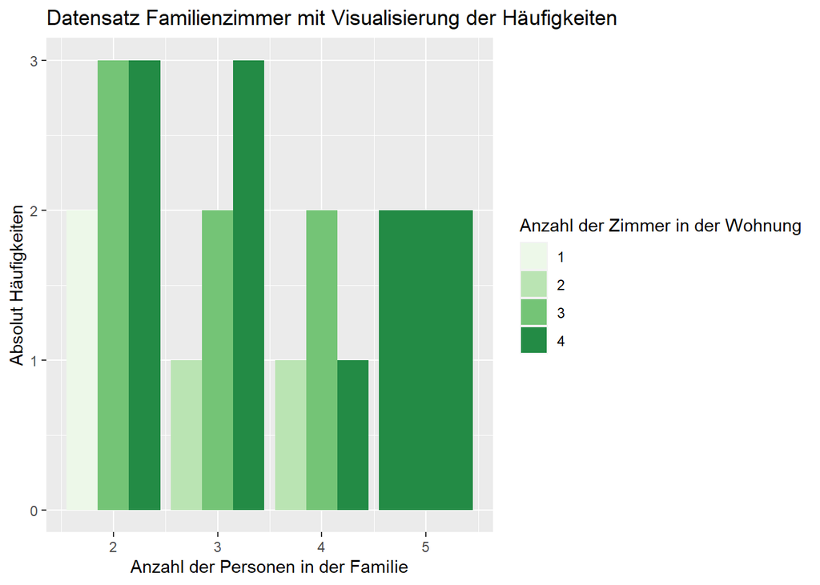

```r
ggplot(data=wohnungen) +
  geom_bar(mapping=aes(x=Personen, fill=factor(Zimmer)),
           position="dodge") +
  scale_fill_brewer(palette="Greens") +
  labs(
         title="Datensatz Familienzimmer mit Visualisierung der Häufigkeiten",
         x="Anzahl der Personen in der Familie",
         y="Absolut Häufigkeiten"
  ) +
  guides(fill=guide_legend(title="Anzahl der Zimmer in der Wohnung"))
```

## 5.2 Streuungsdiagramme

Wir können ein *Streuungsdiagramm*, einen *scatter plot*, für die Werte eines Datensatzes mit zwei oder mehr Merkmalen verwenden. Wir erstellen ein kartesisches Koordinatensystem und tragen die Merkmalsausprägungen für die beiden Merkmale darauf ab.

Streuungsdiagramme können wir bei sehr vielen Werten hervorragend verwenden, um einen Eindruck über die Verteilung der Wertepaare zu erhalten.

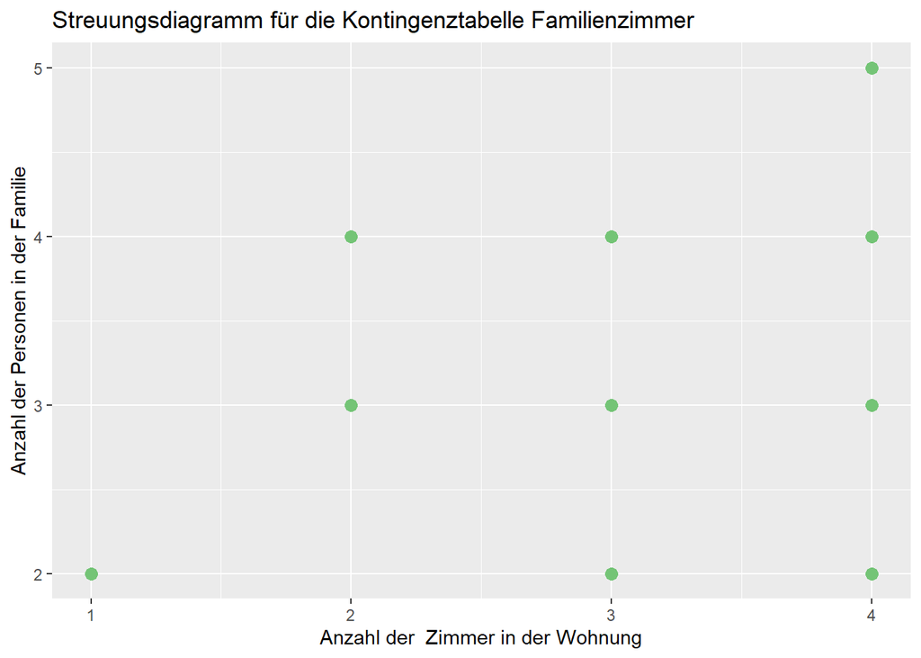

Hier noch eine grafische Ausgabe, die die auftretenden Häufigkeiten mit Hilfe der Größe der Markierungen visualisiert. Dazu verwenden wir die Funktion *geom_count*. Möglich wäre auch die Verwendung von Farben für die Visualisierung der Häufigkeiten.

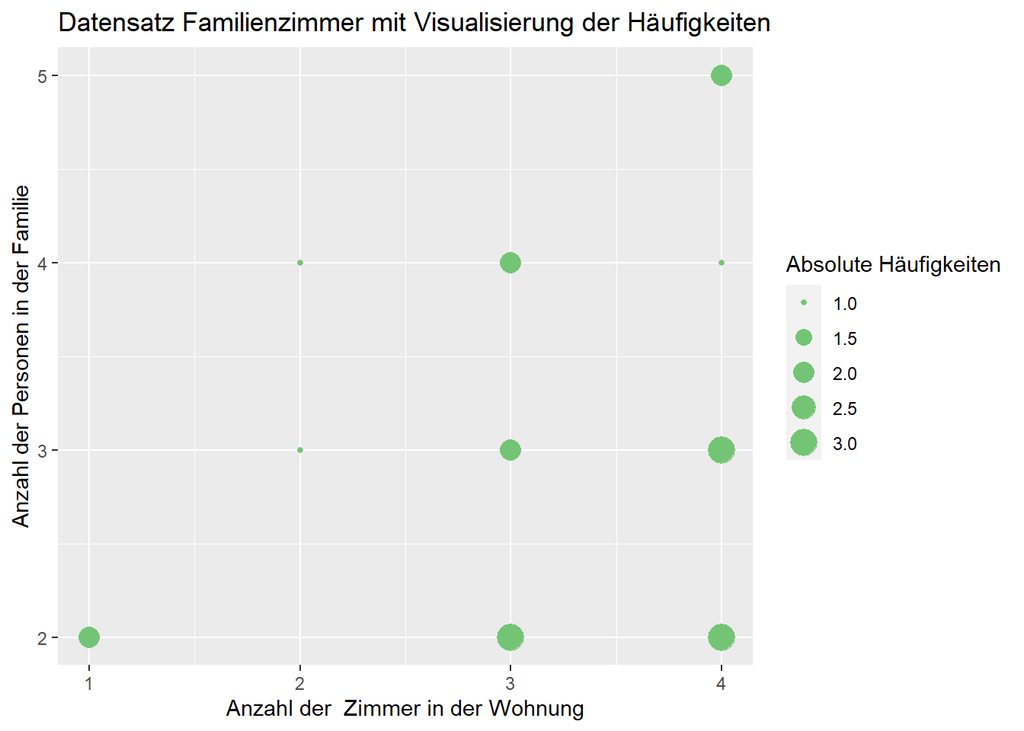

```r
p +
  geom_count(color=myPalette[5]) +
  labs(
         title="Datensatz Familienzimmer mit Visualisierung der Häufigkeiten",
         x="Anzahl der  Zimmer in der Wohnung",
         y="Anzahl der Personen in der Familie"
  ) +
  guides(size=guide_legend(title="Absolute Häufigkeiten", size=2.0))
```

## 5.3 Heatmaps

Wir verwenden Farben um die Häufigkeiten zu visualisieren und erstellen eine Heatmap. Damit wir dies in der dafür vorhandenen Funktion *geom_tile* übergeben können, müssen wir die Daten in das sogenannte *long*-Format in Tidyverse umformatieren. Das *long*-Format entspricht den Daten in der Datei. Wir ergänzen die Daten um eine Spalte, in der die Häufigkeiten für die jeweiligen Wertepaare stehen.

```r
wohnungen.long <- wohnungen %>%
  group_by(Personen, Zimmer) %>%
  mutate(value=n())
```

Jetzt verwenden wir dieses Format und erstellen eine Heatmap:

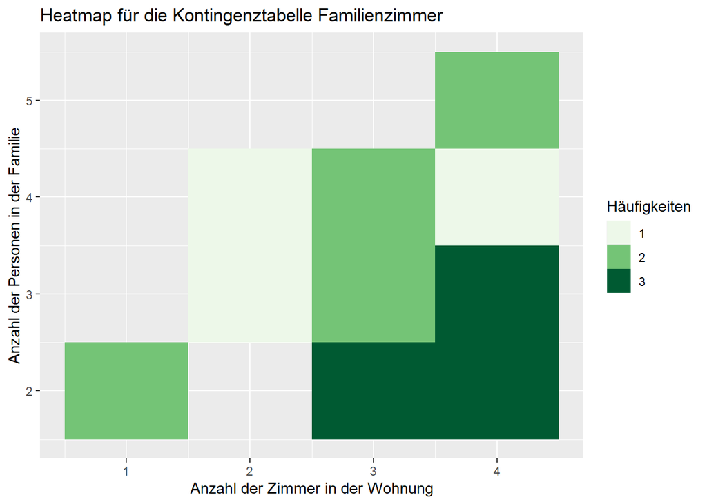

```r
ggplot(data=wohnungen.long) +
  geom_tile(mapping=aes(x=Zimmer, y=Personen, fill=value)) +
  scale_fill_distiller(palette="Greens",
                       guide="legend",
                       limits=c(1,3),
                       breaks=c(1,2,3),
                       direction=1) +
  guides(fill=guide_legend(title="Häufigkeiten")) +
  labs(
    title="Heatmap für die Kontingenztabelle Familienzimmer",
    x="Anzahl der Zimmer in der Wohnung",
    y="Anzahl der Personen in der Familie"
  )
```

```r
ggsave(filename="familienHeat.png", plot=last_plot(),
       device="png",
       path="images/",
       width=16, height=9, units="cm")
```

Es wäre möglich, die Zeilen, in denen die Häufigkeit 0 ist durch diese Zahl zu ergänzen. Zu diesem Fall gibt es im GitHub-Repo von *Tidyverse* eine längere Diskussion. Dazu gibt es die Funktion *complete*, die wir in einer Pipeline einsetzen könnten. Aber auch fehlende Quadrate markieren eigentlich das gleiche - Häufigkeit 0.

## 5.4 Mosaikplots

Eine weitere Möglichkeit der Visualisierungen von Kontingenztabellen sind *mosaicplots*. Hier werden keine Farben für die Visualisierungen der Häufigkeiten eingesetzt, sondern Flächen von Rechtecken werden skaliert und aufgeteilt.

Für die Arbeit mit Kontingenztabellen ist das Package *vcd* sehr nützlich. Dort gibt es die Funktion *mosaic*, mit der wir einen solchen Plot erstellen. Wir wenden die Funktion auf die Kontingenztabelle an:

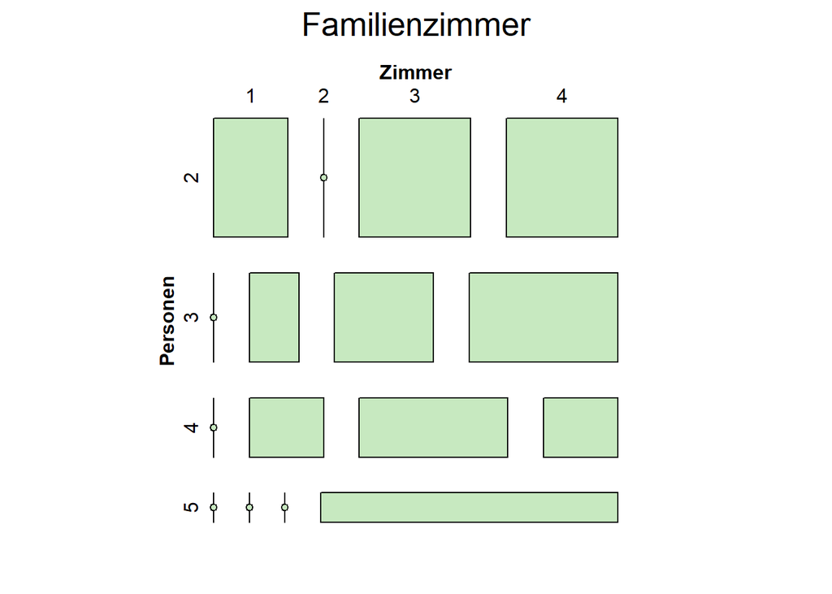

```r
mosaic(wohnungen.table, shade=TRUE,
       highlighting_fill=myPalette[3],
       highlighting = c(2),
       main="Familienzimmer",
       direction=c("h", "v"),
       spacing=spacing_equal(1.5),
       alternate_labels=FALSE,
       zero_shade=FALSE)
```

wir konstruieren einen Mosaikplot in den folgenden Schritten:

- Wir starten mit einer rechteckigen Fläche.
- In Richtung der x-Achse wird die Fläche proportional zu den Häufigkeiten des ersten Merkmals unterteilt.
- Für die Visualisierung des zweiten Merkmals werden die so entstandenen Flächen in Richtung der y-Achse unterteilt, proportional zu den Häufigkeiten des zweiten Merkmals.
- Weitere Merkmale werden analog eingetragen, dabei werden die x- und die y-Achse alternierend verwendet.

Diese Visualisierung hat den offensichtlichen Vorteil, dass man auch mehr als zwei Merkmale visualisieren kann. Wobei dann auch sehr schnell die Übersichtlichkeit liedet.

*ggplot* enthält keine Funktion für die Ausgabe von solchen Plots.

# Literaturverzeichnis

Günter Bamberg, Franz Baur. 1993. *Statistik*. 8. ed. Oldenbourg.